# Breast cancer analysis

Emma Busarello, Gabriele Berrera, Francesco Penasa

## Introduction

Cancer is a complicated disease with each individual tumor exhibiting to a variable degree a set of overlapping phenotypes that include abnormal proliferation and cell survival, genetic instability, tissue invasion, metastasis and angiogenesis. In particular, breast cancer is the most common cancer among women worldwide, representing nearly a quarter (25%) of all cancers with an estimated 2.1 million new cancer cases diagnosed in 2018 (Malvia et al.,). Understanding of deregulated gene expression is therefore an essential goal for cancer research because unraveling this problem will provide insights into the fundamental nature of cancer as well as provide opportunities for therapeutic intervention (Ellis M.J).

## Analysis

RNA-seq count data extracted from TCGA* breast cancer dataset were loaded in RStudio for the analysis. From the original TCGA data only 50 cases (tumor samples) and 50 controls (normal samples) were selected.

https://www.cancer.gov/about-nci/organization/ccg/research/structural-genomics/tcga

The following three dataframes are available:

- raw_counts_df = contains the raw RNA-seq counts
- c_anno_df = contains sample name and condition (Case and Control).
- r_anno_df = contains the ENSEMBL genes ids, the length of the genes and the genes symbols

Only protein coding genes were extracted for subsequent analysis

```r
r_anno_df<-r_anno_df[which(r_anno_df$gene_biotype=="protein_coding"),]
raw_counts_df <- raw_counts_df[which(rownames(raw_counts_df)%in%r_anno_df$ensembl_gene_id),]
```

```r
count_thr <- 20
repl_thr <- 2
filter_vec <- apply(raw_counts_df,1,function(y)
                    max(by(y, c_anno_df$condition, function(x) sum(x>=count_thr))))

filter_counts_df <- raw_counts_df[filter_vec>=repl_thr,]
filter_anno_df <- r_anno_df[rownames(filter_counts_df),]
```

## Differential expression analysis

Differential expression analysis was performed using edgeR package

```r
library("edgeR")
```

Up- and down-regulated genes were selected using a p-value cutoff of 0.01, a log fold change ratio >1.5 for up-regulated genes and < (-1.5) for down-regulated genes and a log2 CPM >1.

Create a DGRList object

```r
edge_c <- DGEList(counts=filter_counts_df,group=c_anno_df$condition,
                  samples=c_anno_df,genes=filter_anno_df)
edge_n <- calcNormFactors(edge_c,method="TMM")  ## Normalization with edgeR (TMM method)
```

Display normalization factors

```r
norm_factors <- mean(edge_n$samples$lib.size*edge_n$samples$norm.factors)/
  (edge_n$samples$lib.size*edge_n$samples$norm.factors)
names(norm_factors) <- edge_n$samples$sample
```

Create a cpm-rpkm table (normalized expression values)

```r
cpm_table <- as.data.frame(round(cpm(edge_n),2))
head(cpm_table)[1:5,1:5] ## visualize the firt 5 rows and 5 columns
```

```
##                 TCGA-AO-A0JD-01A TCGA-AO-A03O-01A TCGA-D8-A1JE-01A
## ENSG00000000003            70.00            70.45            36.39
## ENSG00000000005             0.25             0.45             0.07
## ENSG00000000419            55.22            48.05            49.29
## ENSG00000000457            45.12            38.28            39.13
## ENSG00000000460            47.77            27.97            27.16
##                 TCGA-B6-A1KC-01B TCGA-B6-A0IN-01A
## ENSG00000000003            29.13            54.38
## ENSG00000000005             0.19             2.68
## ENSG00000000419            30.65            19.51
## ENSG00000000457            39.75            22.36
## ENSG00000000460            22.53            12.86
```

Define the experimental design matrix

```r
design <- model.matrix(~0+group, data=edge_c$samples)
colnames(design) <- levels(edge_c$samples$group)
rownames(design) <- edge_c$samples$sample
```

Calculate dispersion and fit with edgeR

```r
edge_d <- estimateDisp(edge_n,design)
edge_f <- glmQLFit(edge_d,design)
```

The function edgeRglmQLF performs differential analysis with edgeR

```r
edgeRglmQLF <- function(mat=edge_f,contro,cpm_mat=edge_n,label="",sig_thr=0.5,sig_col="CPM",
                        fc_thr=0.5,pval_col="p_val",pval_thr=0.05,names=FALSE)
{
  degs <- glmQLFTest(edge_f,contrast=contro)$table[,-3]
  colnames(degs) <- c("log2_FC","log2_CPM","p_val")
  a_levels <- rownames(contro)[which(contro!=0)]
  a_samples <- which(cpm_mat$samples$group%in%a_levels)
  cpm_sele <- cpm(cpm_mat,log=T)[,a_samples]
  degs$log2_CPM <- apply(cpm_sele,1,function(x) mean(x))
  #degs<-exactTest(edge_c, pair=cond, dispersion=bcv^2)$table
  degs$p_adj <- p.adjust(degs$p_val, method ="BH")
  degs$class <- "="
  degs[which(degs[,sig_col]>=sig_thr & degs$log2_FC>=fc_thr & degs[,pval_col]<=pval_thr),
       "class"] <- "+"
  degs[which(degs[,sig_col]>=sig_thr & degs$log2_FC<=(-fc_thr) & degs[,pval_col]<=pval_thr),
       "class"] <- "-"
  degs$class <- as.factor(degs$class)
  degs$comp <- label
  degs$id <- rownames(degs)
  degs <- degs[,c("id","comp","log2_FC","log2_CPM","p_val","p_adj","class")]
  if(names=="TRUE"){
    newnames <- paste(label,colnames(degs),sep="_")
    colnames(degs) <- newnames
  }
  return(degs)
}
```

The function is applied in order to identify differentially expressed genes

```r
contro <- makeContrasts("Case-Control", levels=design) ## definition of the contrast
DEGs <- edgeRglmQLF(mat=edge_f, cpm_mat=edge_n, contro=contro,label = "Control-case",
                    sig_thr=1, sig_col="log2_CPM", fc_thr=1.5, pval_thr=0.01,
                    pval_col="p_adj",names=F)
head(DEGs[order(DEGs$p_adj),])
```

```
##                              id         comp   log2_FC log2_CPM        p_val
## ENSG00000119771 ENSG00000119771 Control-case -3.705115 2.635371 3.083426e-45
## ENSG00000077152 ENSG00000077152 Control-case  3.873831 2.999586 9.831956e-44
## ENSG00000182253 ENSG00000182253 Control-case -5.342195 6.257919 7.645135e-44
## ENSG00000161800 ENSG00000161800 Control-case  2.560776 4.796673 1.161599e-42
## ENSG00000198901 ENSG00000198901 Control-case  3.248113 4.591545 1.008164e-40
## ENSG00000154678 ENSG00000154678 Control-case -4.768672 2.049333 1.463934e-40
##                        p_adj class
## ENSG00000119771 5.474006e-41     -
## ENSG00000077152 5.818224e-40     +
## ENSG00000182253 5.818224e-40     -
## ENSG00000161800 5.155465e-39     +
## ENSG00000198901 3.579588e-37     +
## ENSG00000154678 4.331537e-37     -
```

```r
summary(DEGs$class)
```

```
##     -     +     =
##   990   826 15937
```

Display a Volcano plot of the results:

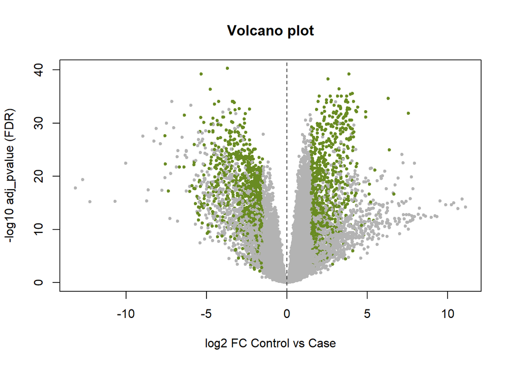

Genes were filtered based on three variables: log2 Fold Change, Minimal log2 CPM value and adjusted pvalue. There are some points, in grey, that have a threshold in the log2 CMP that is lower than 1, but the fold change is higher: they are lowly represent genes in term of counts that are not reliable for differential gene expression analysis.

Heatmap with DEG genes:

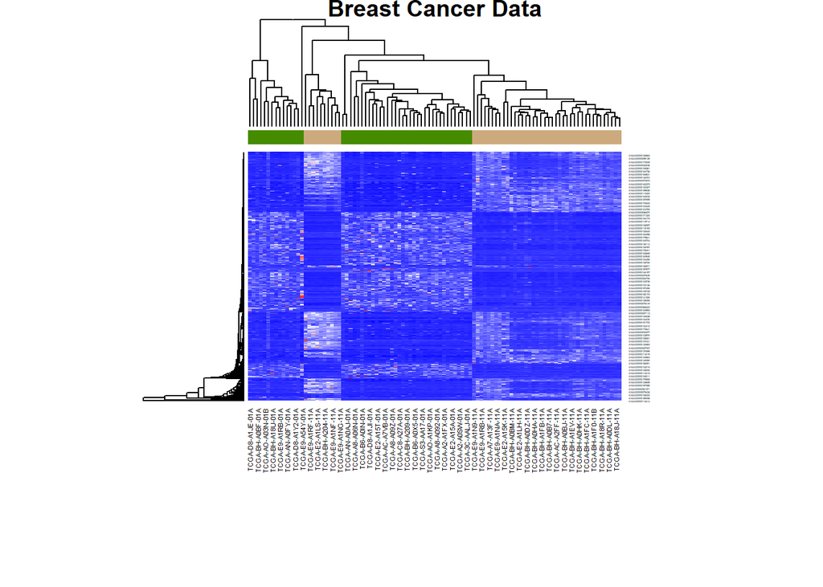

```r
heatmap(as.matrix(cpm_table[which(rownames(cpm_table)%in%DEGs$id[which(DEGs$class!="=")]),]),
        ColSideColors = cols,cexCol = 0.5,margins = c(12,4),col=pal,cexRow = 0.2,
        main="Breast Cancer Data")
```

From the heatmap is possible to observe some differentially expressed genes between the two conditions.

## Gene Set Enrichment Analysis

Both GO and KEGG gene set enrichment analysis were performed using the package **clusterProfiler**. From the list of differentially expressed genes two new lists were created, the first containing the up-regulated and the second the down-regulated genes.

```r
upDEGs <- DEGs %>% filter(class == "+")
downDEGs <- DEGs %>% filter(class == "-")
```

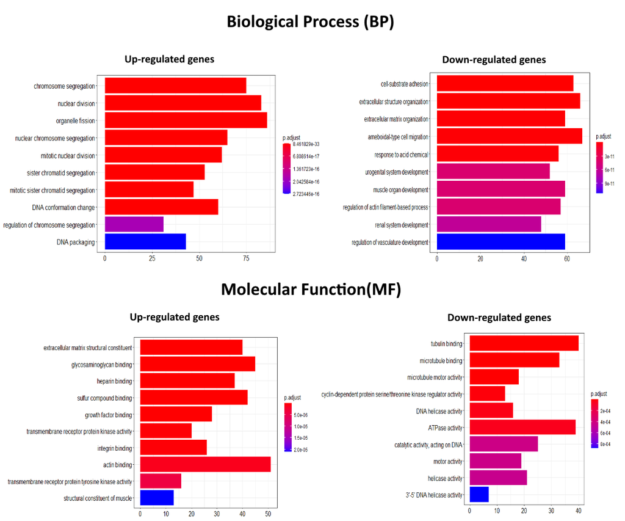

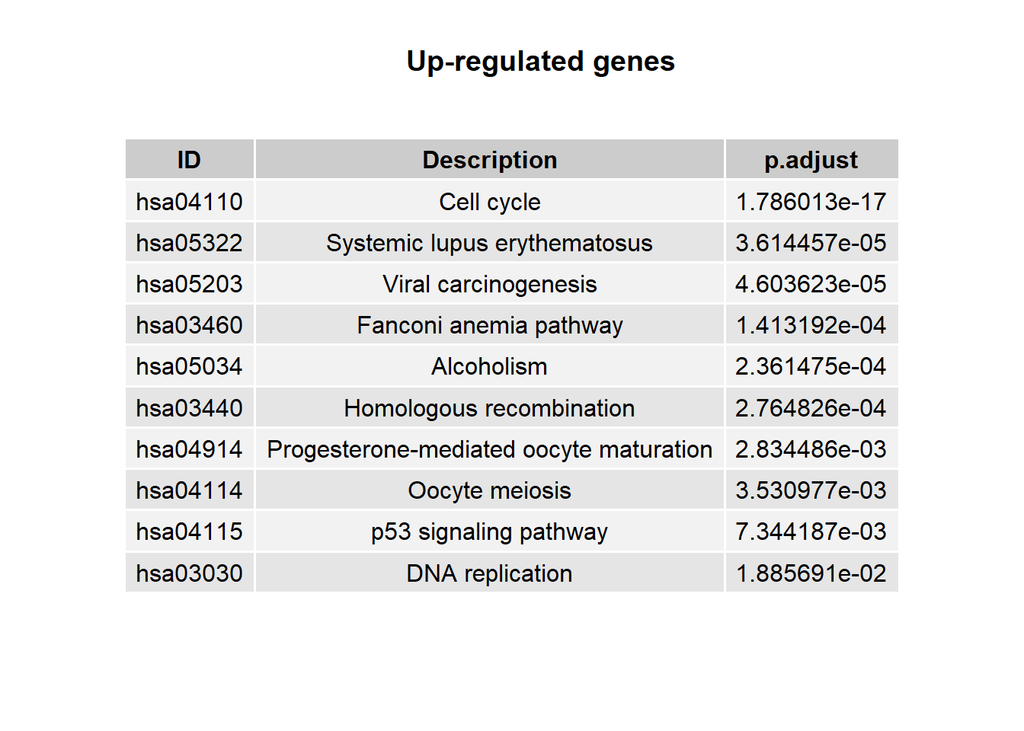

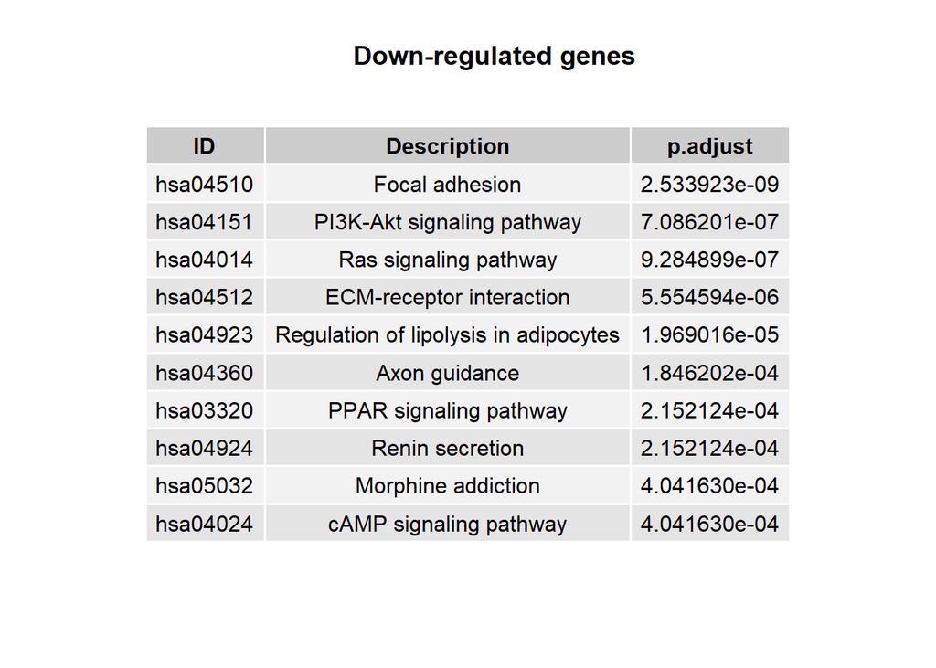

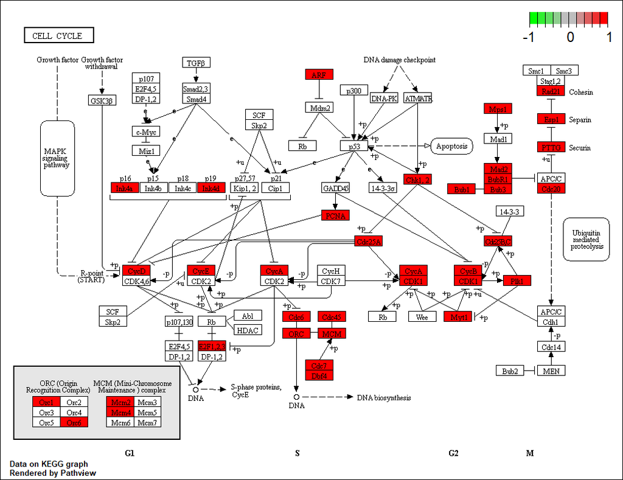

## Motifs Analysis

We identified which transcription factors were enriched in the promoters of all up-regulated genes. First, all the promoter sequences were retrieved using the function **getSequence**, setting a window of 500 nucleotides upstream for each gene.

```r
promoter_seq <- getSequence(id = upDEGs$id,
                            type="ensembl_gene_id",
                            seqType="gene_flank",
                            upstream=500,
                            mart=ensembl)
```

Then the motif enrichment analysis was performed using the function **motifEnrichment**:

```r
data(PWMLogn.hg19.MotifDb.Hsap)
sequences <- lapply(promoter_seq$gene_flank,function(x) DNAString(x))
enriched_TFs <- motifEnrichment(sequences,PWMLogn.hg19.MotifDb.Hsap,score = "affinity")
```

The resulting enriched transcription factors can be visualized in a fansy way using the function **groupReport**:

```r
report = groupReport(enriched_TFs)
```

In the next figure are plotted the top 5 enriched transcription factors resulted from our analysis:

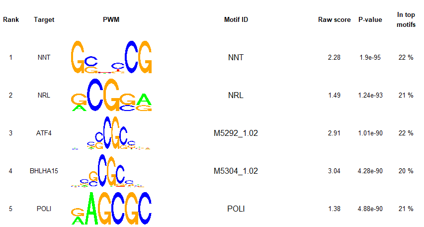

From these top 5 motifs we selected only one of them (we selected the fourth one: **BHLHA15**) and we computed the empirical distributions of scores. For the selected transcription factor we searched for all PWMs in MotifDB:

```r
selected_tf = report$target[4]

tfs_motifs = subset(MotifDb, organism=='Hsapiens' & geneSymbol==selected_tf)
PWM = toPWM(as.list(tfs_motifs))
```

For the selected TF we found 3 PWMs:

- Hsapiens-cisbp_1.02-M5304_1.02
- Hsapiens-jolma2013-BHLHA15
- Hsapiens-SwissRegulon-BHLHA15.SwissRegulon

Then the empirical distribution using the function **motifEcdf**:

```r
ecdf = motifEcdf(PWM,organism = "hg19",quick=TRUE)
```

With this function a distribution is associated at each PWM:

```
## $`Hsapiens-cisbp_1.02-M5304_1.02`
## Empirical CDF
## Call: FUN(X[[i]], ...)
##  x[1:11243] = 1.0639e-15, 1.7185e-15, 2.3732e-15,  ...,  10985,  14929
##
## $`Hsapiens-jolma2013-BHLHA15`
## Empirical CDF
## Call: FUN(X[[i]], ...)
##  x[1:11243] = 1.0639e-15, 1.7185e-15, 2.3732e-15,  ...,  10985,  14929
##
## $`Hsapiens-SwissRegulon-BHLHA15.SwissRegulon`
## Empirical CDF
## Call: FUN(X[[i]], ...)
##  x[1:11243] = 1.0639e-15, 1.7185e-15, 2.3732e-15,  ...,  10985,  14929
```

Then for each motif were caluated the scores with a cutoff theshold of 99.5%

```r
thresholds = lapply(ecdf,function(x) quantile(x,0.995))
scores = motifScores(sequences,PWM,raw.score=FALSE,cutoff=unlist(thresholds))
```

Here are reported the calculated scores for each PWM of the first 10 motifs:

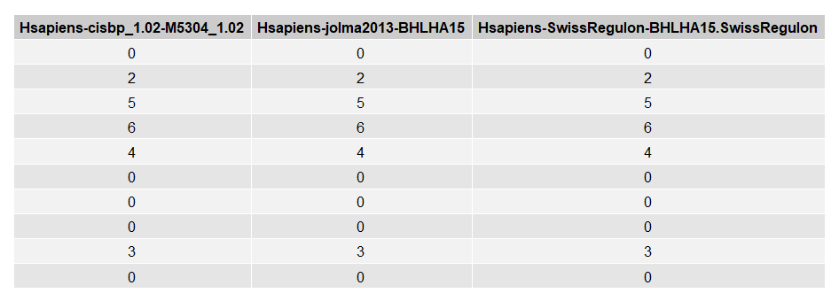

```r
genes_positions <- which(apply(scores,1,function(x){sum(x==0)})==0)
genes_id <- promoter_seq$ensembl_gene_id[genes_positions]
```

The resulting list contains 450 ensembl gene ids of the resulting genes:

```r
length(genes_id) #number of genes
```

```
## [1] 450
```

```r
head(genes_id,10) #first 10 gene ids
```

```
##  [1] "ENSG00000001617" "ENSG00000003249" "ENSG00000006118" "ENSG00000004838"
##  [5] "ENSG00000007968" "ENSG00000010030" "ENSG00000013810" "ENSG00000011426"
##  [9] "ENSG00000024526" "ENSG00000025423"
```

## Results

By performing this analysis we were able to extract some significant information from the RNA-seq data of the patients. In particular, we found the differential expressed genes, distinguished in up- and down-regulated. Computing the GSEA we looked at the the terms and pathways that have become enriched in the breast cancer tumor patients, finding alterations for example in:

- **Biological Processes:** the most over-represented biological processes are related with the cell cycle: chromosome segregation, nuclear division, organelle fission, etc. Deregulation of the cell cycle is a hallmark of cancer that enables limitless cell division. To support this malignant phenotype, cells acquire molecular alterations that abrogate or bypass control mechanisms in signaling pathways and cellular checkpoints that normally function to prevent genomic instability and uncontrolled cell proliferation (Thu et al.,) Some of the most under-represented processes are related with extracellular matrix (ECM): cell-substrate adhesion, extracellular structure organization, extracellular matrix organization, etc. The ECM constitutes a complex of structural proteins and its reorganization is essential during cancer progression. These proteins provide biochemical signals to promote metastasis progression of cancer to advanced stage. In addition, various ECM proteins such as integrins, collagen and fibronectin engage in cell adhesion, invasion and metastasis (Jena et al.,).
- **Molecular Functions:** the most over-represented molecular functions are extracellular matrix structural constituent, glycosaminoglycan binding and heparin binding. Linear glycosaminoglycan (GAG) chains constitute proteoglycans that are expressed on the cell surface, cytoplasm, and extracellular matrix and regulate cell migration, invasion and growth of various cancer cells (Iida et al.,). The up-regulation of heparin-binding growth factors represents a mechanism by which cancer cells can enhance growth factor signaling (Lai et al.,). The most under-represented molecular functions are tubulin binding, microtubulue binding and microtuble motor activity. Microtubules are highly dynamic cytoskeletal fibres that are composed of tubulin subunits and are involved in cell movement, intracellular trafficking, and mitosis.In the context of cancer, the tubulin family of proteins is recognized as the target of the tubulin-binding chemotherapeutics, which suppress the dynamics of the mitotic spindle to cause mitotic arrest and cell death. Changes in microtubule stability and the expression of different tubulin isotypes have been reported for a range of cancers. These changes have been correlated with poor prognosis and chemotherapy resistance.  
  Emerging evidence suggests that tubulins and microtubule-associated proteins may play a role in a range of cellular stress responses, thus conferring survival advantage to cancer cells (Parker et al.,)
- **Pathways:** the most enriched pathways, resulted from KEEG analysis, are related with the cell cycle and all the signaling pathway regulating it. From the the up-regulated lists of genes, the systemic lupus erythematosus shows a significant result: evidence of possible links between systemic lupus erythematosus (SLE) and cancer has generated much interest. Recent studies have shown an increased risk of hematological malignancies and a decreased risk of some reproductive malignancies (Cloutier et al.,). Enriched KEGG pathways resulting from the down-regulated lists of genes are involved in the extracellular signals such as the PI3K-Akt pathway that mediates the effects of a variety of extracellular signals in a number of cellular processes including cell growth, proliferation, and survival.The frequent dysregulation of the PI3K/Akt pathway in breast cancer can increases the activation status of the signaling and can thus lead to cellular transformation (Castaneda et al.,). The engagement of RAS function might be mandatory downstream varied oncogenic alterations for the progression, metastatic dissemination, and therapy resistance in breast cancers (Galiè).

## References:

1. KL Thu, Soria-Bretones, TW Mak, DW Cescon. Cell Cycle 2018. Targeting the cell cycle in breast cancer: toward the next phase. 2.Manoj Kumar Jena, Jagadeesh Janjanam. F1000Research 2018. Role of extracellular matrix in breast cancer development:a brief update.
2. Joji Iida, Jesse Dorchak. Rebecca Clancy, Juliana Slavik, Rachel Ellsworth, Yasuhiro Katagiri, Elena N.Pugacheva, Toin H.van Kuppevelt, Richard J.Mural, Mary LouCutler, Craig D.Shriver. Experimental Cell Research 2015. Role for chondroitin sulfate glycosaminoglycan in NEDD9-mediated breast cancer cell growth 4.Jinping Lai, Jeremy Chien, Julie Staub, Rajeswari Avula, Eddie L. Greene, Tori A. Matthews, David I. Smith, Scott H. Kaufmann, Lewis R. Roberts, Viji Shridhar.The Journal of Biological Chemistry 2003. Loss of HSulf-1 Up-regulates Heparin-binding Growth Factor Signaling in Cancer.
3. Amelia L. Parker, Maria Kavallaris, Joshua A. McCarroll. Front Oncol. 2014. Microtubules and Their Role in Cellular Stress in Cancer
4. B. Tessier Cloutier, A. E. Clarke, R. Ramsey-Goldman, Y. Wang, W. Foulkes, C. Gordon, J. E. Hansen, E. Yelin, M. B. Urowitz, D. Gladman, P. R. Fortin, D. J. Wallace, M. Petri, S. Manzi, E. M. Ginzler, J. Labrecque, S. Edworthy, M. A. Dooley, J. L. Senécal, C. A. Peschken, S. C. Bae, D. Isenberg, A. Rahman, G. Ruiz-Irastorza, J. G. Hanly, S. Jacobsen, O. Nived, T. Witte, L. A. Criswell, S. G. Barr, L. Dreyer, G. Sturfelt, S. Bernatsky, and Systemic Lupus International Collaborating Clinics (SLICC). Oncology 2013. Breast Cancer in Systemic Lupus Erythematosus
5. Carlos A. Castaneda, Hernán Cortes-Funes, Henry L. Gomez, Eva M. Ciruelos. Cancer and Metastasis Reviews 2010. The phosphatidyl inositol 3-kinase/AKT signaling pathway in breast cancer.
6. Mirco Galiè. Front Oncol 2019. RAS as Supporting Actor in Breast Cancer
7. A. Sethuraman, M. Brown, Krutilina , Zhao-Hui Wu, Tiffany N. Seagroves, Lawrence M. Pfeffer, Meiyun Fan. Breast Cancer Res 2018. Sethuraman, A., Brown, M., Krutilina, R. et al. BHLHE40 confers a pro-survival and pro-metastatic phenotype to breast cancer cells by modulating HBEGF secretion.
8. Matthew J. Ellis (2003). Breast Cancer Gene Expression Analysis. In: Llombart-Bosch A., Felipo V. (eds) New Trends in Cancer for the 21st Century. Advances in Experimental Medicine and Biology, vol 532. Springer, Boston, MA
9. Malvia, S., Bagadi, S.A.R., Pradhan, D. et al. Study of Gene Expression Profiles of Breast Cancers in Indian Women. Sci Rep 9, 10018 (2019)